# Project Proposal - Generating HEC Timetable

Matteo Gross, Alessia Di Pietro, Martina Celic, Ana Gabriela Garcia, Laura Lo Priore

2021-11-07

# 1 Introduction

## 1.1 Brief Rationales

As per now, university students struggle every semester to create a timetable. In fact, there are many possible combinations of classes that would meet the criterion of their studies. But how to visualize all that satisfy the time constraints (impossible to follow two classes taking place at the same time), the modules ones (specific to each university curriculum) and total ECTS constraints (on average 30 ECTS credits must be completed) easily ?

The current solution most students follow is based on trial and error, but it result is somehow inefficient: as soon as a first suitable schedule is found, the student stops searching, even if he/she could have been happier with possible another timetable not discovered.

## 1.2 Overall Objectives

The objective is to design an optimization algorithm that would generate all possible timetables from a choice of possible classes. From our perspective of Master students in Management at HEC Lausanne, following the track “Business Analytics”, we face every semester the following challenge, in the sense that we must choose classes that account for 3 constraints: (1) the **time reality**, (2) the **“modules” allocation** and (3) the **total ECTS credits**.

## 1.3 Potential Impacts

While we first aim to focus on creating a optimization tool for Business Analytics students at HEC Lausanne, this algorithm could be easily scaled up to be used with other orientations for instance of the Master in Management. If successful, we can imagine that the HEC administration could offer such solutions to all of its students (Bsc/Msc).

# 2 Plan

## 2.1 Approach and Specific Objectives

As we all come from different universities and countries, it is interesting to see how each one of them works regarding timetable creation for classes. We can cite, for instance, Tecnológico de Monterrey, which is one of our team mates former university. It offers a software which, according to the courses a student has chosen, displays in green and blue how some courses overlap, as well as some information in red also about the course availability. While this is useful for students, it still takes a while to get a “doable” timetable, so we want to tackle this problem.

As previously explained, the goal of this project is to create an algorithm that would generate all possible timetables from a choice of possible classes. Focusing on the specific case of the Master in Management at HEC Lausanne, and especially on the track of “Business Analytics”, the project would take into account specifically:

- the **time constraints** (clashing classes on the schedule are impossible to take),
- the **“modules” ECTS constraints** (classes are either in *Business Analytics* or *Electives*),
- the **total ECTS credits constraints** (do more than *X* ECTS credits for each semester).

What is more, it should offer the possibility to users to also pre-select some classes they are sure to take, as well as how many ECTS credits in total they need, and the relative allocation between their main track and the count of Electives. Otherwise, we could also imagine suggesting timetables only based on the user preferences.

### 2.1.1 Potential Extensions

As an extension, the program could also consider more than one semester, as students generally need to achieve Module ECTS constraints over Semester 2 and Semester 3. While this optimization tool is aimed first for Business Analytics students at HEC Lausanne, if successful, it could be scaled up to be used with other orientations. The ultimate goal would be that HEC would offer it to its students.

## 2.2 Data collection

To obtain the data, we will simply copy paste the timetable from the HEC website, following the following link: https://hecnet.unil.ch/hec/timetables/snc_de_pub?pub_id=20491&dyn_lang=fr.

We could also imagine to web-scrap the data directly from the web, to fully automate the process.

We will then clean it and add manually the information about the “Modules” (BA, Marketing, SOL, BEE).

As per now, one of the risks we can present is that the timetable is in constant change. For instance, for the semester Autumn 2021, the correct timetable with all the correct courses that were to be imparted was lastly modified even during the semester. This is a risk that is not in our hands. Definitely this is something that the university should start to work on.

Out of that, we don’t see the data collection as very problematic, except maybe for the automation. We should also taken into account that when the syllabus is updated, data should be recollected.

## 2.3 Methods and Alternatives

We will rely on Integer Linear Programming, possibly using packages such as `lpSolve` or `ompr`, as well as `fastDummies`, to create dummy variables. Overall, we aim to solve the following models:

- **variables to optimize**: dummy (1= taking, 0= not taking) for each class
- **objective function**: minimize the credits to be done each semester
- **constraints**:
  - time: two classes can’t be taken at the same time (defined time slot of 60 minutes)
  - modules ECTS: *X* credits must be achieved in BA, *Y* credits must be achieved with Electives
  - total ECTS: *Z* credits must be achieved at least

While it seems simple, we need to account for the overlapping classes (such as classes from 8-10 on Monday can’t be combined with classes from 8-12 on Monday), so we need specific modeling. Further, we will allow the user to input his/her specific requirements (e.g. free on Monday, 12 credits in BA and 15 in Elective, total credits only 27) via the implementation of the Shiny app.

In case we are unsuccessful with the Integer Optimization, we could still generate randomly many combinations of classes, and then check to see if such combinations meet the requirements of students, as well as the time constraints (with a matrix of “overlapping” classes). In this way, we have an alternative to Integer Linear Programming.

# 3 Timeline and milestones

The following chart displays the planned theoretical workflow for our project, with the sub-steps. As it is a plan, it will likely to evolve over time. Basically, each week we need to have one milestone **M** completed.

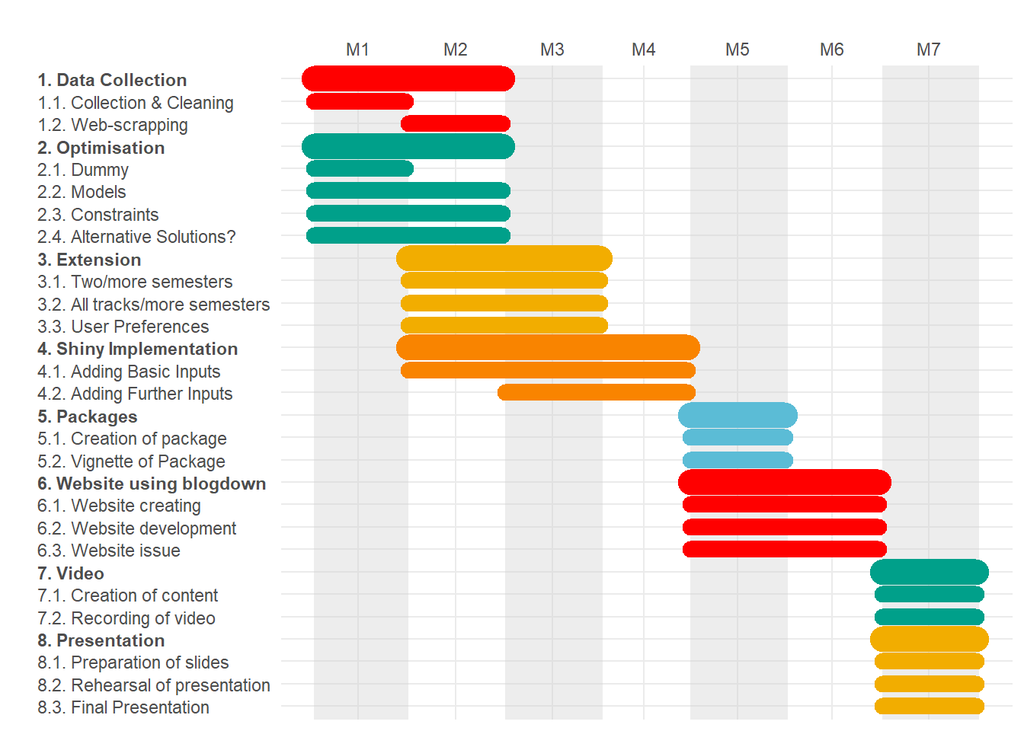

# 4 Management Plan

For our management plan, we have the advantage that we all, as a team, come to campus on a daily basis. We believe that having weekly meetings on campus for organization and deciding what is our next approach is better than having this on zoom. This since in this way is easier to make questions and even do some progress in the code together.

To have a better organization and to optimize this as much as possible, we have thought of the following management plan:

- Matteo: Data/Web-scrapping
- Laura: Optimization & Extension
- Ana Gaby: Extension
- Martina: Website + Packages
- Alessia: Shiny app
- All: Video + Presentation